# kNN example 1 - Normalizing features and applying resampling methods

Vijayakumar Jawaharlal

April 23, 2014

- Cross Validation
- Boot Strap
- Using fixed sample

Package *e1071* is going to be used for resampling methods. This package has bunch tools to tune various parameters to find out best performance from the model. It has very good support functions for svm, random forest, decision tree, knn etc., Refer help pages for e1071 package.

tune.knn() function is going to be used for resampling. I may need to use tune.control(), summary and plot to depict the results from tune.knn()

```r
normalize <- function(x) {
    norm <- ((x - min(x))/(max(x) - min(x)))
    return (norm)
}


marketSample <- function(smarkt, test_pct = 20) {
    train_pct = 100 - test_pct
    #Seeding for reproducibility
    set.seed(test_pct)
    test_indx <- sample(nrow(smarkt), nrow(smarkt) * test_pct/100, replace=FALSE)
    test.all <- smarkt[test_indx,]

    test.data <- test.all[,-9]
    test.direction <- test.all$Direction

    #Prep. training data  which is noting but remaing test data
    train.all <- smarkt[-test_indx,]
    train.data <- train.all[,-9]
    train.direction <- train.all$Direction

    rtrn_list <- list(testdata = test.data, testdir = test.direction, traindata = train.data, traindir = train.direction)

    return(rtrn_list)

}
```

Data prep using normalize function

```r
library(ISLR)
input.norml <- as.data.frame(lapply(Smarket[,-9],normalize))
input.norml$Direction <- Smarket$Direction

full.data <- input.norml[,-9]
full.dir <- input.norml[,9]

temp_list <- marketSample(input.norml, 20)
train.data <- temp_list$traindata
train.dir <- temp_list$traindir

test.data <- temp_list$testdata
test.dir <- temp_list$testdir

rm(temp_list)
```

Let us apply various resampling method to find out optimal K.

Let us go with k-fold cross validation to find out the optimal k value for knn()

```r
library(e1071)
#Full Data set can be used for cross validation
knn.cross <- tune.knn(x = full.data, y = full.dir, k = 1:20,tunecontrol=tune.control(sampling = "cross"), cross=10)
#Summarize the resampling results set
summary(knn.cross)
```

```
##
## Parameter tuning of 'knn.wrapper':
##
## - sampling method: 10-fold cross validation
##
## - best parameters:
##   k
##  19
##
## - best performance: 0.1248
##
## - Detailed performance results:
##     k  error dispersion
## 1   1 0.1856    0.03180
## 2   2 0.2184    0.03524
## 3   3 0.1687    0.02999
## 4   4 0.1703    0.03122
## 5   5 0.1583    0.03067
## 6   6 0.1599    0.03427
## 7   7 0.1511    0.03273
## 8   8 0.1368    0.02053
## 9   9 0.1432    0.03268
## 10 10 0.1544    0.03372
## 11 11 0.1424    0.03966
## 12 12 0.1471    0.03280
## 13 13 0.1375    0.03457
## 14 14 0.1416    0.03347
## 15 15 0.1384    0.03056
## 16 16 0.1400    0.03759
## 17 17 0.1279    0.03740
## 18 18 0.1272    0.02638
## 19 19 0.1248    0.03225
## 20 20 0.1280    0.02410
```

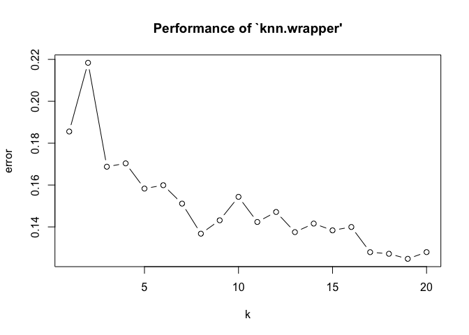

```r
#Plot the error rate
plot(knn.cross)
```

Resampling using bootstraping

```r
#Full Data set can be used for cross validation
knn.boot <- tune.knn(x = full.data, y = full.dir, k = 1:20,tunecontrol=tune.control(sampling = "boot") )
#Summarize the resampling results set
summary(knn.boot)
```

```
##
## Parameter tuning of 'knn.wrapper':
##
## - sampling method: bootstrapping
##
## - best parameters:
##   k
##  20
##
## - best performance: 0.1599
##
## - Detailed performance results:
##     k  error dispersion
## 1   1 0.2027   0.011899
## 2   2 0.2177   0.016510
## 3   3 0.2180   0.008659
## 4   4 0.2092   0.012496
## 5   5 0.1956   0.017534
## 6   6 0.1906   0.019819
## 7   7 0.1912   0.021306
## 8   8 0.1856   0.019959
## 9   9 0.1818   0.023124
## 10 10 0.1796   0.017639
## 11 11 0.1777   0.018028
## 12 12 0.1748   0.013825
## 13 13 0.1737   0.017660
## 14 14 0.1773   0.017987
## 15 15 0.1716   0.017996
## 16 16 0.1682   0.019212
## 17 17 0.1659   0.023116
## 18 18 0.1658   0.024365
## 19 19 0.1605   0.020610
## 20 20 0.1599   0.022703
```

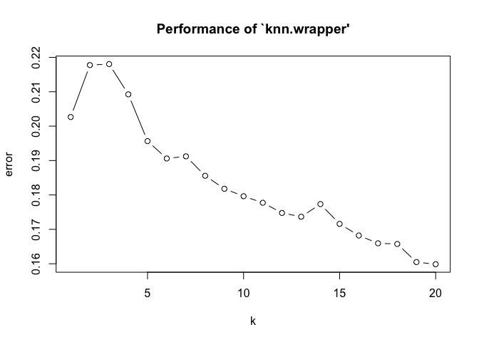

```r
#Plot the error rate
plot(knn.boot)
```

Resampling fixed set

```r
#Full Data set can be used for cross validation
knn.fix <- tune.knn(x = full.data, y = full.dir, k = 1:20,tunecontrol=tune.control(sampling = "fix") , fix=10)
#Summarize the resampling results set
summary(knn.fix)
```

```
##
## Parameter tuning of 'knn.wrapper':
##
## - sampling method: fixed training/validation set
##
## - best parameters:
##  k
##  7
##
## - best performance: 0.1487
##
## - Detailed performance results:
##     k  error dispersion
## 1   1 0.1871         NA
## 2   2 0.2134         NA
## 3   3 0.1703         NA
## 4   4 0.1751         NA
## 5   5 0.1583         NA
## 6   6 0.1655         NA
## 7   7 0.1487         NA
## 8   8 0.1751         NA
## 9   9 0.1631         NA
## 10 10 0.1631         NA
## 11 11 0.1535         NA
## 12 12 0.1751         NA
## 13 13 0.1535         NA
## 14 14 0.1607         NA
## 15 15 0.1727         NA
## 16 16 0.1679         NA
## 17 17 0.1775         NA
## 18 18 0.1583         NA
## 19 19 0.1679         NA
## 20 20 0.1775         NA
```

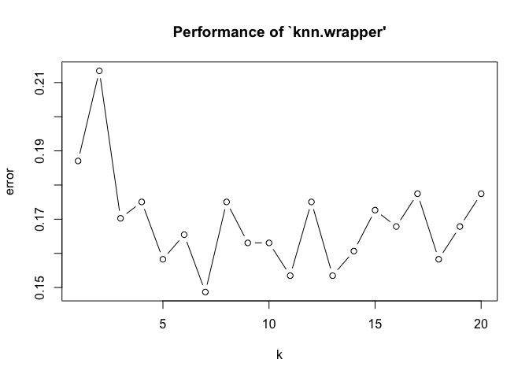

```r
#Plot the error rate
plot(knn.fix)
```

```r
library(class)
knn.pred <- knn(train = train.data,test = test.data,cl = train.dir,k = 19)
table(knn.pred,test.dir)
```

```
##         test.dir
## knn.pred Down  Up
##     Down  103  11
##     Up     19 117
```

```r
mean(knn.pred == test.dir)
```

```
## [1] 0.88
```

```r
knn.pred1 <- knn(train = train.data,test = test.data,cl = train.dir,k = 20)
table(knn.pred1,test.dir)
```

```
##          test.dir
## knn.pred1 Down  Up
##      Down  107  10
##      Up     15 118
```

```r
mean(knn.pred1 == test.dir)
```

```
## [1] 0.9
```

Prediction accuracy is now about 88 to 90%. This is much much improved result than previous script “knn_example1_imprvd”